# Estimating Probability with Sampling

Math 340 Hitchman

We can use repeated sampling of some chance experiment to estimate the probability of some event.

# 1. Rolling a 10-sided Die

> We roll a 10 sided die. Find the probability that the first time we roll an 8 or higher is on the 5th roll.

**Scratch Work**

1. Simulate rolling a 10-sided die 5 times. We can do so by sampling with replacement from the integers 1-10

```r
rolls=sample.int(10,5,replace=TRUE)
rolls
```

```
## [1] 3 5 4 9 2
```

For the purposes of this discussion, let’s say a sequence of 5 rolls is *good* if the first 4 rolls are less than 8, and the last roll is 8 or greater.

2. We want code to check whether a random sequence of 5 rolls is *good*.

Notice that `rolls[1]` gives the value of the first roll:

```r
rolls[1]
```

```
## [1] 3
```

and `rolls[1]<8` is a statement that is either TRUE or FALSE

```r
rolls[1]<8
```

```
## [1] TRUE
```

and this records whether each of the 5 rolls does what it needs to do for the sequence to be *good*:

```r
c(rolls[1:4]<8,rolls[5]>=8)
```

```
## [1]  TRUE  TRUE  TRUE FALSE FALSE
```

and the `sum()` of this vector of TRUE/FALSEs counts the number of TRUE values. We need the sum to be 5 to have a *good* sequence of 5 rolls.

```r
sum(c(rolls[1:4]<8,rolls[5]>=8))
```

```
## [1] 3
```

**Final Code**

```r
trials=10000
results=c()
for (i in 1:trials){
  rolls=sample.int(10,5,replace=TRUE) # roll the 10-sided die 5 times
  good.count=sum(c(rolls[1:4]<8,rolls[5]>=8)) #how many of the 5 rolls do what they need to in order to have a good sequence
  results=c(results,good.count) # record the number of 8s in the results vector
}
table(results)
```

```
## results
##    0    1    2    3    4    5
##   56  545 2046 3696 2928  729
```

Based on this simulation, we estimate the probability of a *good* sequence of 5 rolls by the proportion of time the good.count vector took a value of 5.

```r
sum(results=="5")/trials
```

```
## [1] 0.0729
```

This estimate is close to what we calculated by our counting tools
$$\frac{7^4\cdot 3}{10^5}\approx
.07203.$$

# 2. Marbles from an urn

> An urn that contains 100 orange and 200 green marbles. If you draw 8 marbles at random (without replacement), how likely is it that more than 5 of them are orange?

```r
urn = rep(c("O","G"),c(100,200))
trials=1000
results=c()
for (i in 1:trials){
  grab=sample(urn,8,replace=FALSE)
  oranges=sum(grab=="O")
  results=c(results,oranges)
}
table(results)
```

```
## results
##   0   1   2   3   4   5   6   7
##  32 169 284 284 163  50  15   3
```

We can enter `sum(results>5)` to see how often we grabbed more than 5 orange marbles in our sample of size 8, and `sum(results>5)/trials` is a good estimate of the likelihood of this happening. Conclusion: It appears we should expect the more than 5 orange marbles in our sample of 8 about 1.8% of the time:

```r
sum(results>5)/trials
```

```
## [1] 0.018
```

Note this question is a classic “good potatoes/bad potatoes” problem, and by our counting techniques, we know the probability is
$$\frac{\binom{100}{6}\cdot\binom{200}{2}}{\binom{300}{8}}+
\frac{\binom{100}{7}\cdot\binom{200}{1}}{\binom{300}{8}}+
\frac{\binom{100}{8}\cdot\binom{200}{0}}{\binom{300}{8}},$$
which we can evaluate in R as a check:

```r
sum(choose(100,6:8)*choose(200,8-6:8)/choose(300,8))
```

```
## [1] 0.01830405
```

*Note*: After studying common named discrete probability distributions, we will see that R has a nice built-in command for doing these sorts of computations.

# 3. Splitting a set into multiple subsets

> A committee has 12 people: 6 republicans, 4 democrats, and 2 independents. The committee is randomly divided into 3 subgroups of size 5, 4, and 3. What is the probability that the 2 independents are in the same subgroup?

**One approach**:

1. Build the committee

```r
committee=rep(c("R","D","I"),c(6,4,2))
```

We can always check to make sure it looks right:

```r
table(committee)
```

```
## committee
## D I R
## 4 2 6
```

2. Partition the members into three subgroups of size 5, 4, and 3. Our approach: shuffle the order of all 12 members, take the first five for subgroup 1, the next 4 for subgroup 2, and the last 3 for subgroup 3.

```r
shuffle=sample(committee,12,replace=FALSE)
sub1=shuffle[1:5]
sub2=shuffle[6:9]
sub3=shuffle[10:12]
# the code below displays the subgroups as a check
print(sub1)
```

```
## [1] "D" "I" "D" "D" "R"
```

```r
print(sub2)
```

```
## [1] "I" "R" "D" "R"
```

```r
print(sub3)
```

```
## [1] "R" "R" "R"
```

3. Check whether both independents are in the same subgroup. We can determine the number of “I”s in each group using `sum(group=="I")`, and calculate the maximum of these three counts.

```r
max(sum(sub1=="I"),sum(sub2=="I"),sum(sub3=="I"))
```

```
## [1] 1
```

4. We see that both “I”s are in the same group if the max above equals 2. We can record our result using an `ifelse()` command. The following code will produce 1 if the max “I” count equals 2, and 0 if it doesn’t.

```r
ifelse(max(sum(sub1=="I"),sum(sub2=="I"),sum(sub3=="I"))==2,1,0)
```

```
## [1] 0
```

**Final Code**

We put it all together now. We repeat this process for 10000 trials: Partition the committee into the three subgroups, record 1 if both “I”s find themselves in the same group, and 0 otherwise. We store these 1s and 0s in the vector `results`.

```r
trials=10000
results=c()
for (i in 1:trials){
  shuffle=sample(committee,12,replace=FALSE) #randomly shuffles the 12 people.
  sub1=shuffle[1:5]  # first 5 in the random shuffling go to subgroup 1
  sub2=shuffle[6:9] # next 4 to subgroup 2
  sub3=shuffle[10:12] # last 3 to subgroup 3
  #are both "I"s in the same subgroup? We record 1 if "yes", and 0 if "no"
  results=c(results,ifelse(max(sum(sub1=="I"),sum(sub2=="I"),sum(sub3=="I"))==2,1,0))
}
table(results)
```

```
## results
##    0    1
## 7121 2879
```

Based on this simulation, we estimate the probability that both “I”s end up in the same subgroup as

```r
sum(results)/trials
```

```
## [1] 0.2879
```

This estimate is close to what we calculated by our counting tools:
$$\frac{\binom{10}{3~4~3}+\binom{10}{5~2~3}+\binom{10}{5~4~1}}{\binom{12}{5~4~3}}$$
which evaluates to 7980/27720 $\approx 0.288$:

```r
(factorial(10)/(6*24*6)+factorial(10)/(120*2*6)+factorial(10)/(120*24*1))/(factorial(12)/(120*24*6))
```

```
## [1] 0.2878788
```

# 4. Oregon License Plates

> Classic Oregon license plates consist of 3 letters (A-Z) followed by 3 numbers (0-9). Find the probability that a randomly selected plate has two 8s.

**Scratch Work**

```r
LETTERS
```

```
##  [1] "A" "B" "C" "D" "E" "F" "G" "H" "I" "J" "K" "L" "M" "N" "O" "P" "Q" "R" "S"
## [20] "T" "U" "V" "W" "X" "Y" "Z"
```

```r
plate=c(sample(LETTERS,3,replace=TRUE),sample(0:9,3,replace=TRUE))
plate
```

```
## [1] "B" "C" "W" "7" "6" "5"
```

2. We can record the number of “8”s in the plate

```r
sum(plate=="8")
```

```
## [1] 0
```

**Final Code**

```r
trials=10000
results=c()
for (i in 1:trials){
  plate=c(sample(LETTERS,3,replace=TRUE),sample(0:9,3,replace=TRUE)) #build a plate
  eights=sum(plate=="8")
  results=c(results,eights) # record the number of 8s in the results vector
}
table(results)
```

```
## results
##    0    1    2    3
## 7267 2462  266    5
```

Based on this simulation, we estimate the probability of having a plate with exactly 2 “8”s

```r
sum(results=="2")/trials
```

```
## [1] 0.0266
```

This estimate is close to what we calculated by our counting tools:

$$\frac{26\cdot 26\cdot 26 \cdot
\binom{3}{2} \cdot 1 \cdot 1 \cdot 9}{26^3\cdot 10^3}= \frac{27}{1000} =
0.027.$$

# 5. Pollsters

> In an upcoming election for mayor of a large city, a pollster plans to predict the winner of the popular vote by taking a random sample of 1000 voters and declaring that the winner will be the one obtaining the most votes in his sample. Suppose that 48 percent of the voters plan to vote for the Republican candidate and 52 percent plan to vote for the Democratic candidate. To get some idea of how reasonable the pollster’s plan is, write a program to make this prediction by simulation. Repeat the simulation 1000 times and see how many times the pollster’s prediction would come true.

First, let’s create and summarize a single poll of 1000 people from a population in which 52 percent are “D”, and 48 percent are “R”.

```r
one.poll=sample(c("D","R"),1000,replace=TRUE,prob=c(.52,.48))
table(one.poll)
```

```
## one.poll
##   D   R
## 502 498
```

Of course, the goal is to use the poll to predict the winner of the election, and R can record the predicted winner for us with the `ifelse()` command. We use the `sum()` command to count how many elements in the one.poll vector equal “D” (use those double equal signs).

```r
ifelse(sum(one.poll=="D")>500,"Dem wins","Tie or Rep wins")
```

```
## [1] "Dem wins"
```

Now, our goal is to repeat this sampling and prediction procedure 1000 times, and keep track of how likely it is to predict correctly that the democratic candidate will win.

```r
# specify the voting population
dem=.52 #proportion voting "D"
rep=1-dem # proportion voting "R"
poll.size=1000 # poll sample size

trials=1000

result=rep("",trials) #creating a vector in which to record each poll's prediction
for (i in 1:trials){
  poll <- sample(c("D","R"),poll.size,replace=TRUE,p=c(dem,rep))
  result[i]=ifelse(sum(poll=="D")>poll.size/2,"D","Tie or R")
}
table(result)
```

```
## result
##        D Tie or R
##      880      120
```

This table gives us a sense of the likelihood that the pollsters plan will result in an accurate prediction of which candidate will win the election. Based on our simulation, that likelihood is about 0.88.

# 6. Matching Birthdays

> Suppose you ask $n$ random people their birthday (month and day, disregarding year). What is the probability that at least one of them share your birthday? What is the probability that at least two of them share the same birthday? (Assume 365 days in a year - ignore leap days.)

We tackle the first question by first computing the probability that none of the $n$ people share my birthday. The probability that a random person does not have my birthday is $\frac{364}{365}$, and the probability that $n$ random people all do not have my birthday is $\left(\frac{364}{365}\right)^n$.

The *complement* of this event is that at least one of the $n$ people has my birthday, and so the probability of this will be $1- \left(\frac{364}{365}\right)^n$.

We can write a function in R to compute this probability for various values of $n$.

```r
my.bday <- function(n){
  return(1-(364/365)^n)
}
```

For instance, in a group of 15 people here’s the probability that someone shares my birthday:

```r
my.bday(15)
```

```
## [1] 0.04031703
```

Not too likely!

For the second question, we begin by calculating the probability that no one in a group of $n$ people shares the same birthday as anyone else.

So, we need all $n$ people to have a different birthday. This probability is found in essentially the same way that you answered #6 in Homework 2, and it equals
$$\frac{P^n_r}{365^n}=\frac{365\cdot 364 \cdot
\cdots \cdot (365-n+1)}{365^n}.$$
So, the probability that at least two people share the same birthday, which is the complement of “no one shares the same birthday” is
$$1 -
\frac{365\cdot 364 \cdot \cdots \cdot (365-n+1)}{365^n}.$$

For instance, in a group of 6 people, the probability that at least two people share a birthday is
$$1-1 \cdot
\frac{364}{365}\cdot\frac{363}{365}\cdot
\frac{362}{365}\cdot\frac{361}{365}\cdot\frac{360}{365}\approx0.04.$$

Here’s a function that will compute this probability for any group size $n$.

```r
shared.bday <- function(n){
  p=1
  for (i in 1:n){
    p=p*(365-i+1)/365
  }
  return(1-p)
}
```

For instance, in a group of 15 people here’s the probability that at least two people share a birthday

```r
shared.bday(15)
```

```
## [1] 0.2529013
```

Whoa! A 25 percent chance! In fact, it turns out we only need 23 people gathered in a room to have a 50 percent chance that two of them share a birthday! Also, with a group of 59 people we have a 99 percent chance of a birthday match: `shared.bday(59)`=0.993.

Here’s a graph of these two probabilities for values of $1 \leq n \leq 100$.

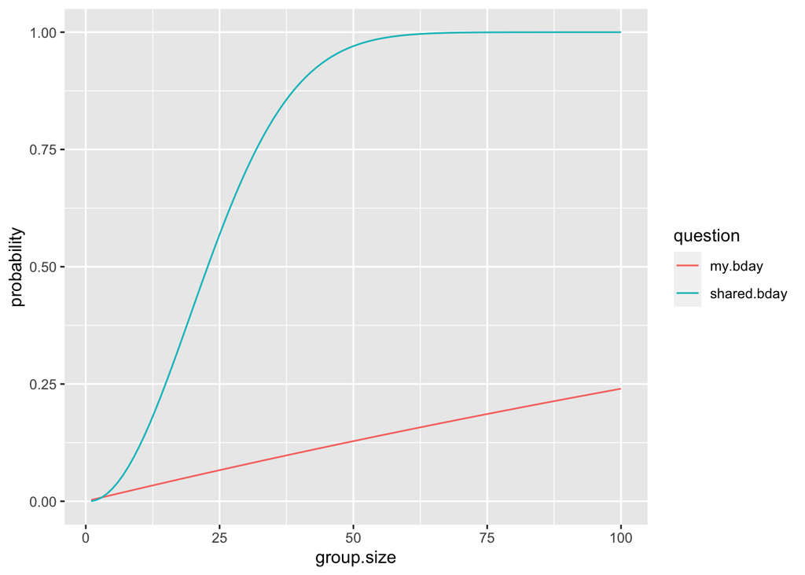

```r
library(tidyverse)
sh=c()
for (i in 1:100){
  sh=c(sh,shared.bday(i))
}
my=c()
for (i in 1:100){
  my=c(my,my.bday(i))
}
df <- data.frame(group.size=1:100,my.bday=my,shared.bday=sh)
df_long <- df%>% gather(question, probability, c(my.bday,shared.bday))

ggplot(df_long)+
  geom_line(aes(x=group.size,y=probability,col=question))
```